# Lab 10: Interaction terms in Linear Regression

# Introduction

This is Lab 10 on Data Mining. It describes how one can use interaction terms in linear regression.

First we load the `datamining` package and the data for the lab.

```r
devtools::load_all()
```

```
i Loading datamining
```

```r
load('lab9.rda')
```

# The data set

The dataset is the same as lab 9. As before, we transform the variable `Sold.4` and standardize all variables to mean zero and variance one. The data.frame `xx` holds the standardised variables.

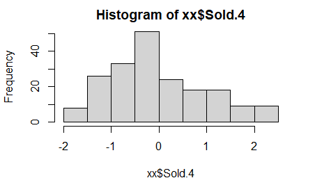

```r
xx <- x[, c(ncol(x), 1:ncol(x)-1)]
xx$Sold.4 <- log(xx$Sold.4)
xx <- as.data.frame(scale(xx))
hist(xx$Sold.4)
```

# Selecting interaction terms

First we make a linear model to predict `Sold.4` from all product prices.

```r
fit <- lm(Sold.4 ~ ., data=xx)
summary(fit)
```

```
Call:
lm(formula = Sold.4 ~ ., data = xx)

Residuals:
     Min       1Q   Median       3Q      Max
-1.64931 -0.52982 -0.06812  0.56385  1.64732

Coefficients:
              Estimate Std. Error t value Pr(>|t|)
(Intercept)  1.320e-15  5.144e-02   0.000  1.00000
Price.1     -6.389e-02  5.506e-02  -1.160  0.24738
Price.2     -1.500e-03  6.880e-02  -0.022  0.98263
Price.3      2.130e-02  5.783e-02   0.368  0.71304
Price.4     -6.531e-01  5.761e-02 -11.337  < 2e-16 ***
Price.5      8.692e-01  2.913e-01   2.984  0.00323 **
Price.6     -6.336e-02  8.810e-02  -0.719  0.47298
Price.7     -6.891e-01  2.916e-01  -2.363  0.01918 *
Price.8     -4.441e-02  5.535e-02  -0.802  0.42344
Price.9      1.607e-03  5.883e-02   0.027  0.97824
Price.10     4.824e-02  6.371e-02   0.757  0.44992
Price.11     2.911e-01  6.090e-02   4.780 3.58e-06 ***
---
Signif. codes:  0 ‘***’ 0.001 ‘**’ 0.01 ‘*’ 0.05 ‘.’ 0.1 ‘ ’ 1

Residual standard error: 0.7201 on 184 degrees of freedom
Multiple R-squared:  0.5107,    Adjusted R-squared:  0.4815
F-statistic: 17.46 on 11 and 184 DF,  p-value: < 2.2e-16
```

We use `step` to automatically select important interaction terms whilst keeping all the single variable terms in the model. Unimportant interaction terms are automatically dropped.

A regression formula is an object in R and can be manipulated programmatically. For example, we can extract formula used in the linear regression above and modify it to include all the interaction terms.

```r
message('Original formula')
```

```
Original formula
```

```r
linear_fm <- formula(terms(fit))
print(linear_fm)
```

```
Sold.4 ~ Price.1 + Price.2 + Price.3 + Price.4 + Price.5 + Price.6 +
    Price.7 + Price.8 + Price.9 + Price.10 + Price.11
```

```r
message('Updated formula')
```

```
Updated formula
```

```r
update.formula(linear_fm, Sold.4 ~ .^2)
```

```
Sold.4 ~ Price.1 + Price.2 + Price.3 + Price.4 + Price.5 + Price.6 +
    Price.7 + Price.8 + Price.9 + Price.10 + Price.11 + Price.1:Price.2 +
    Price.1:Price.3 + Price.1:Price.4 + Price.1:Price.5 + Price.1:Price.6 +
    Price.1:Price.7 + Price.1:Price.8 + Price.1:Price.9 + Price.1:Price.10 +
    Price.1:Price.11 + Price.2:Price.3 + Price.2:Price.4 + Price.2:Price.5 +
    Price.2:Price.6 + Price.2:Price.7 + Price.2:Price.8 + Price.2:Price.9 +
    Price.2:Price.10 + Price.2:Price.11 + Price.3:Price.4 + Price.3:Price.5 +
    Price.3:Price.6 + Price.3:Price.7 + Price.3:Price.8 + Price.3:Price.9 +
    Price.3:Price.10 + Price.3:Price.11 + Price.4:Price.5 + Price.4:Price.6 +
    Price.4:Price.7 + Price.4:Price.8 + Price.4:Price.9 + Price.4:Price.10 +
    Price.4:Price.11 + Price.5:Price.6 + Price.5:Price.7 + Price.5:Price.8 +
    Price.5:Price.9 + Price.5:Price.10 + Price.5:Price.11 + Price.6:Price.7 +
    Price.6:Price.8 + Price.6:Price.9 + Price.6:Price.10 + Price.6:Price.11 +
    Price.7:Price.8 + Price.7:Price.9 + Price.7:Price.10 + Price.7:Price.11 +
    Price.8:Price.9 + Price.8:Price.10 + Price.8:Price.11 + Price.9:Price.10 +
    Price.9:Price.11 + Price.10:Price.11
```

We use the updated formula in the `scope` argument of the `step` function. The function starts with the full `fit` model and then selectively adds interactions terms. The summary shows the final model.

```r
fit_int <- step(fit, scope = list(upper=~.^2, lower=~.), trace = 0)
summary(fit_int)
```

```
Call:
lm(formula = Sold.4 ~ Price.1 + Price.2 + Price.3 + Price.4 +
    Price.5 + Price.6 + Price.7 + Price.8 + Price.9 + Price.10 +
    Price.11 + Price.8:Price.11 + Price.2:Price.5 + Price.8:Price.9 +
    Price.3:Price.10 + Price.2:Price.3 + Price.1:Price.3, data = xx)

Residuals:
     Min       1Q   Median       3Q      Max
-1.45989 -0.49602 -0.01199  0.48409  1.64410

Coefficients:
                 Estimate Std. Error t value Pr(>|t|)
(Intercept)       0.02361    0.05853   0.403 0.687084
Price.1          -0.11565    0.05759  -2.008 0.046137 *
Price.2           0.02103    0.06804   0.309 0.757561
Price.3           0.09275    0.06144   1.510 0.132908
Price.4          -0.66827    0.05677 -11.771  < 2e-16 ***
Price.5           0.95282    0.28457   3.348 0.000992 ***
Price.6          -0.11348    0.08657  -1.311 0.191629
Price.7          -0.75018    0.28338  -2.647 0.008843 **
Price.8          -0.02423    0.05867  -0.413 0.680109
Price.9           0.03068    0.05829   0.526 0.599268
Price.10          0.10484    0.06309   1.662 0.098318 .
Price.11          0.38510    0.06267   6.145 5.11e-09 ***
Price.8:Price.11 -0.14961    0.06112  -2.448 0.015334 *
Price.2:Price.5  -0.09298    0.04647  -2.001 0.046902 *
Price.8:Price.9   0.11214    0.05288   2.120 0.035359 *
Price.3:Price.10  0.17454    0.07168   2.435 0.015881 *
Price.2:Price.3  -0.13702    0.05915  -2.316 0.021672 *
Price.1:Price.3  -0.09641    0.05711  -1.688 0.093136 .
---
Signif. codes:  0 ‘***’ 0.001 ‘**’ 0.01 ‘*’ 0.05 ‘.’ 0.1 ‘ ’ 1

Residual standard error: 0.6889 on 178 degrees of freedom
Multiple R-squared:  0.5668,    Adjusted R-squared:  0.5254
F-statistic:  13.7 on 17 and 178 DF,  p-value: < 2.2e-16
```

You can set `trace = 1` in the function call to see intermediate output from `step`. There are six bilinear terms.

A plot of each term against its partial residuals is shown below.

```
plotting partial residuals
```

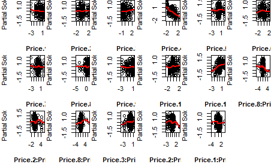

```r
predict_plot(fit_int, partial = TRUE)
```

# Visualization

A contour plot matrix shows the contribution of each interaction term to the model.

```
plotting residuals
```

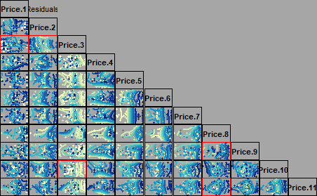

```r
interact.plot(fit_int)
```

Find the ‘strongest’ and ‘weakest’ interactions that you identified earlier. Do the contours agree with that ranking ?

Slice plots show the type of the interaction. First we examine the interaction `Price.8:Price.11`.

```r
r <- partial.residual.frame(fit_int, "Price.8*Price.11")
```

This sets `r` to a matrix with three columns: `Price.8`, `Price.11`, and `Sold.4` (`Sold.4` is the partial residuals for a model with `Price.8` and `Price.11` completely excluded). Notice that you put `*` between the variable names, not `:`.

```r
color.plot(smooth(Sold.4 ~ Price.8 + Price.11, r), n=8)
```

[output not shown]

[output cut: 56 more lines]

[output not shown]

```r
slices(Sold.4 ~ Price.8 | Price.11, r)
```

[output not shown]

```r
predict_plot(Sold.4 ~ Price.8 | Price.11, r, n=4)
```

[output not shown]

10. Make slice plots of the top 4 interactions. They should show the type of each interaction. (As a check, the contour plot of each interaction should be the same as in the plot above.) For each, you have to decide which is the better variable to slice on.